# Brainstorm: more views on the Innovation Graph × HDI data

## Idea 9: when each tier first showed up on emerging topics

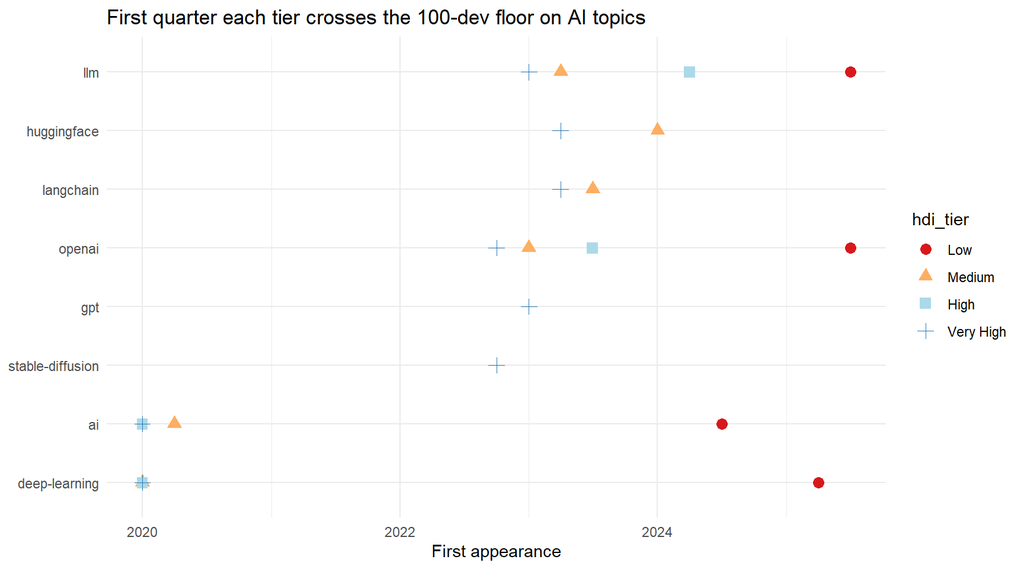

```r
emerging <- c("llm", "ai", "langchain", "deep-learning", "stable-diffusion",
              "openai", "gpt", "huggingface")

topics |>
  filter(topic %in% emerging) |>
  inner_join(hdi |> select(iso2_code, hdi_tier), by = "iso2_code") |>
  group_by(topic, hdi_tier, year, quarter) |>
  summarise(pushers = sum(num_pushers), .groups = "drop") |>
  filter(pushers > 0) |>
  group_by(topic, hdi_tier) |>
  slice_min(year * 10 + quarter, n = 1) |>
  mutate(first_q = yq(paste0(year, " Q", quarter))) |>
  ggplot(aes(first_q, fct_reorder(topic, as.numeric(first_q)),
             color = hdi_tier, shape = hdi_tier)) +
  geom_point(size = 3) +
  scale_color_brewer(palette = "RdYlBu") +
  labs(title = "First quarter each tier crosses the 100-dev floor on AI topics",
       x = "First appearance", y = NULL)
```

## Idea 10: topic peak quarter — what’s rising vs. falling

For the top 40 topics, when did each peak? A topic peaking *recently* is rising; peaking in 2020-2021 is fading. Color = direction.

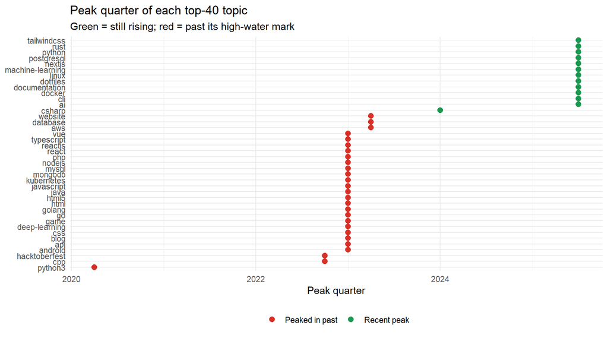

```r
top_topics <- topics |>
  group_by(topic) |>
  summarise(total = sum(num_pushers), .groups = "drop") |>
  slice_max(total, n = 40)

peaks <- topics |>
  semi_join(top_topics, by = "topic") |>
  group_by(topic, year, quarter) |>
  summarise(pushers = sum(num_pushers), .groups = "drop") |>
  group_by(topic) |>
  slice_max(pushers, n = 1) |>
  mutate(peak_q = yq(paste0(year, " Q", quarter)))

ggplot(peaks, aes(peak_q, fct_reorder(topic, peak_q),
                  color = year >= 2024)) +
  geom_point(size = 2.5) +
  scale_color_manual(values = c("TRUE" = "#1a9850", "FALSE" = "#d73027"),
                     labels = c("FALSE" = "Peaked in past", "TRUE" = "Recent peak"),
                     name = NULL) +
  labs(title = "Peak quarter of each top-40 topic",
       subtitle = "Green = still rising; red = past its high-water mark",
       x = "Peak quarter", y = NULL) +
  theme(legend.position = "bottom")
```

## Idea 11: pushers-per-developer intensity by tier

`languages.csv` counts language-pushers (a dev who pushes 3 languages counts 3×). `developers.csv` counts unique devs. Their ratio = breadth of activity per developer. Does the average dev push more languages in high-HDI economies?

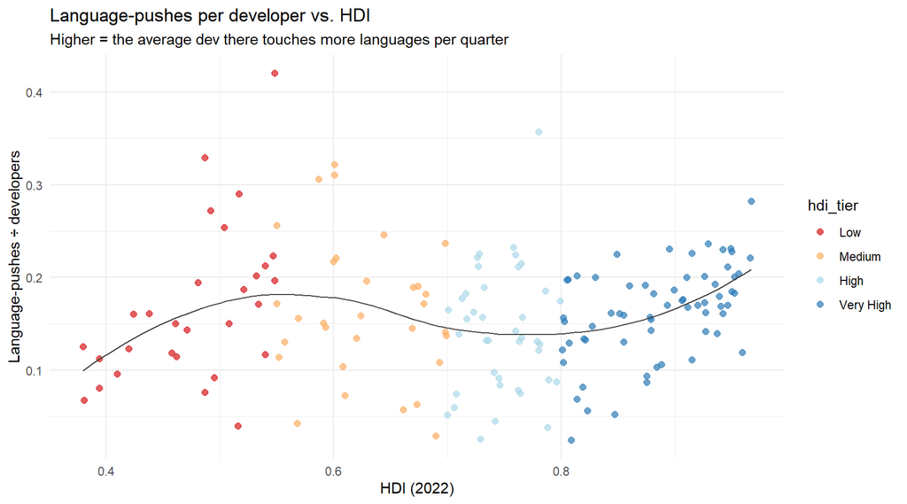

```r
intensity <- langs_snap |>
  group_by(iso2_code, hdi_tier, hdi_2022) |>
  summarise(lang_pushes = sum(num_pushers), .groups = "drop") |>
  inner_join(devs_snap |> select(iso2_code, developers),
             by = "iso2_code") |>
  mutate(pushes_per_dev = lang_pushes / developers) |>
  filter(developers >= 200)

ggplot(intensity, aes(hdi_2022, pushes_per_dev, color = hdi_tier)) +
  geom_point(alpha = 0.7, size = 2) +
  geom_smooth(se = FALSE, method = "loess", formula = y ~ x,
              color = "grey25", linewidth = 0.5) +
  scale_color_brewer(palette = "RdYlBu") +
  labs(title = "Language-pushes per developer vs. HDI",
       subtitle = "Higher = the average dev there touches more languages per quarter",
       x = "HDI (2022)", y = "Language-pushes ÷ developers")
```

## Idea 12: outliers — punching above their HDI weight

Fit `log(developers) ~ HDI` across countries; pull the biggest positive and negative residuals. These are the economies that have *more* (or less) GitHub presence than their HDI predicts.

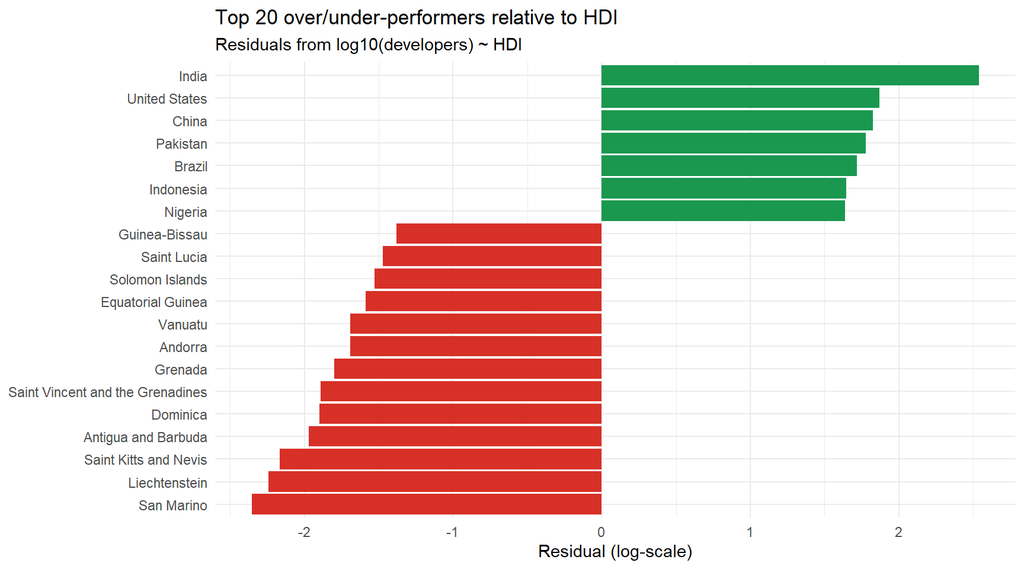

```r
fit_df <- devs_snap |>
  filter(developers >= 1000) |>
  mutate(log_devs = log10(developers))

m <- lm(log_devs ~ hdi_2022, data = fit_df)

fit_df |>
  mutate(resid = resid(m)) |>
  slice_max(abs(resid), n = 20) |>
  ggplot(aes(resid, fct_reorder(country, resid), fill = resid > 0)) +
  geom_col() +
  scale_fill_manual(values = c("TRUE" = "#1a9850", "FALSE" = "#d73027"),
                    guide = "none") +
  labs(title = "Top 20 over/under-performers relative to HDI",
       subtitle = "Residuals from log10(developers) ~ HDI",
       x = "Residual (log-scale)", y = NULL)
```

## Idea 13: country language-rank stability

For each country’s top language, how stable is that ranking over time? Plot rank-of-top-language across quarters for the 12 biggest economies.

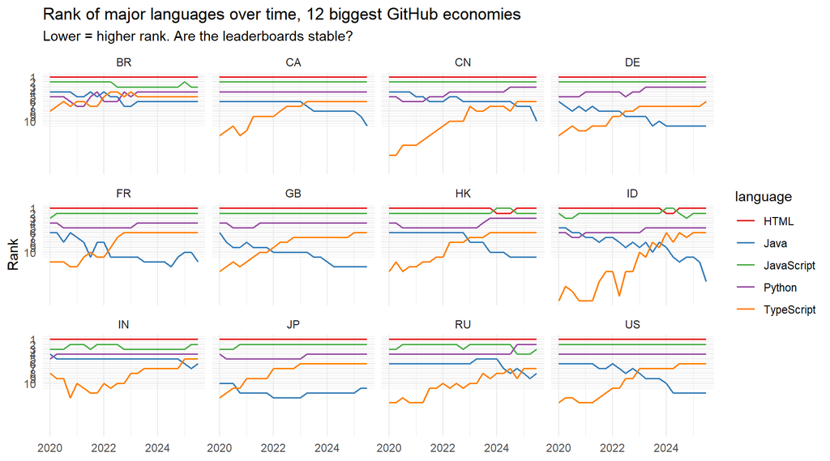

```r
big12 <- devs_snap |> slice_max(developers, n = 12) |> pull(iso2_code)

ranks <- langs |>
  filter(iso2_code %in% big12) |>
  group_by(iso2_code, year, quarter) |>
  mutate(rank = rank(-num_pushers, ties.method = "min")) |>
  ungroup() |>
  filter(language %in% c("Python", "JavaScript", "Java", "TypeScript", "HTML")) |>
  mutate(date = yq(paste0(year, " Q", quarter)))

ggplot(ranks, aes(date, rank, color = language)) +
  geom_line(linewidth = 0.7) +
  scale_y_reverse(breaks = 1:10) +
  facet_wrap(~ iso2_code, ncol = 4) +
  scale_color_brewer(palette = "Set1") +
  labs(title = "Rank of major languages over time, 12 biggest GitHub economies",
       subtitle = "Lower = higher rank. Are the leaderboards stable?",
       x = NULL, y = "Rank")
```

## Idea 14: repos per developer — productivity proxy

Per-country average of repos / developers, faceted by tier. Captures “output per head” rather than total mass.

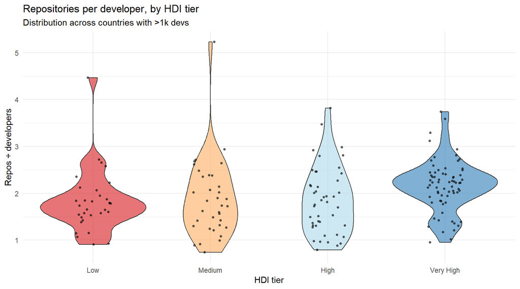

```r
repos_snap |>
  inner_join(devs_snap |> select(iso2_code, developers),
             by = "iso2_code") |>
  filter(developers >= 1000) |>
  mutate(ratio = repositories / developers) |>
  ggplot(aes(hdi_tier, ratio, fill = hdi_tier)) +
  geom_violin(alpha = 0.6) +
  geom_jitter(width = 0.15, alpha = 0.6, size = 1) +
  scale_fill_brewer(palette = "RdYlBu", guide = "none") +
  labs(title = "Repositories per developer, by HDI tier",
       subtitle = "Distribution across countries with >1k devs",
       x = "HDI tier", y = "Repos ÷ developers")
```

## Idea 15: AI/LLM explosion line chart

Specifically the 2023-2024 inflection on AI-adjacent topics, indexed to their respective 2020-Q1 baselines.

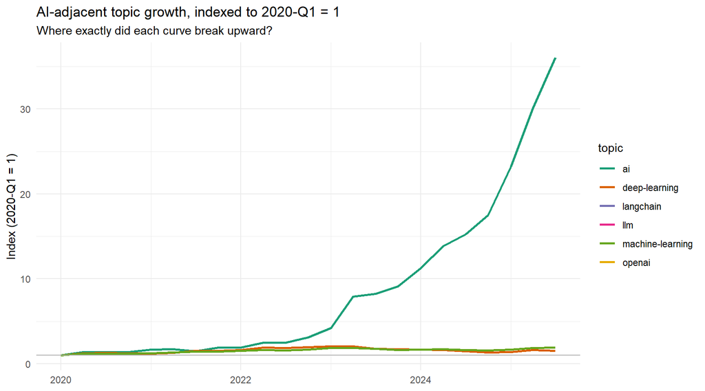

```r
ai_topics <- c("ai", "llm", "deep-learning", "machine-learning",
               "openai", "langchain")

ai_panel <- topics |>
  filter(topic %in% ai_topics) |>
  group_by(topic, year, quarter) |>
  summarise(pushers = sum(num_pushers), .groups = "drop") |>
  group_by(topic) |>
  mutate(base = first(pushers[year == 2020 & quarter == 1]),
         index = pushers / base,
         date = yq(paste0(year, " Q", quarter)))

ggplot(ai_panel, aes(date, index, color = topic)) +
  geom_line(linewidth = 0.9) +
  geom_hline(yintercept = 1, color = "grey70") +
  scale_color_brewer(palette = "Dark2") +
  labs(title = "AI-adjacent topic growth, indexed to 2020-Q1 = 1",
       subtitle = "Where exactly did each curve break upward?",
       x = NULL, y = "Index (2020-Q1 = 1)")
```

## Idea 16: language-family × tier alluvial / stacked

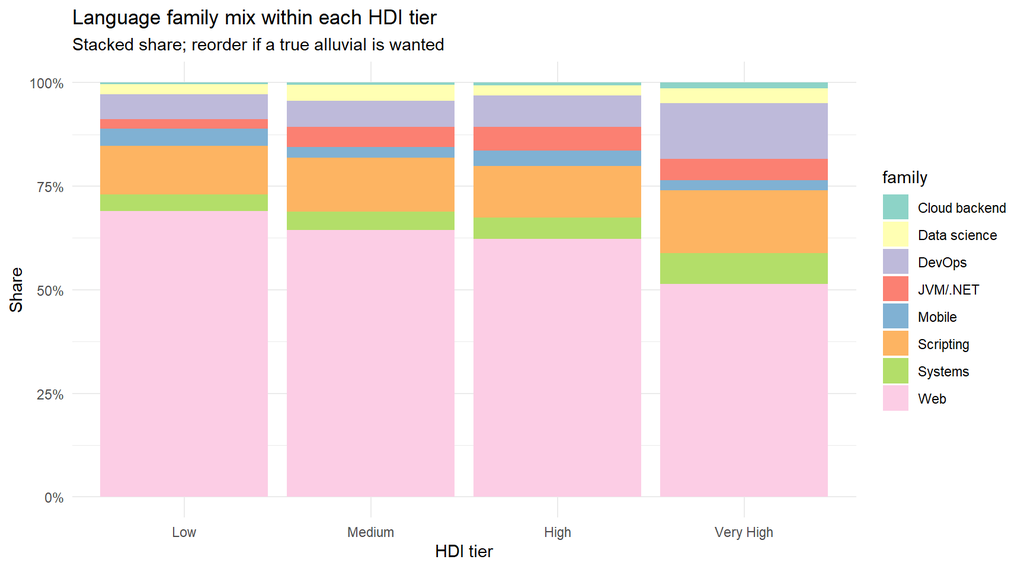

```r
families <- tibble::tribble(
  ~language,        ~family,
  "Python",         "Scripting",
  "Ruby",           "Scripting",
  "PHP",            "Scripting",
  "JavaScript",     "Web",
  "TypeScript",     "Web",
  "HTML",           "Web",
  "CSS",            "Web",
  "Java",           "JVM/.NET",
  "C#",             "JVM/.NET",
  "Kotlin",         "Mobile",
  "Swift",          "Mobile",
  "Dart",           "Mobile",
  "C",              "Systems",
  "C++",            "Systems",
  "Rust",           "Systems",
  "Go",             "Cloud backend",
  "Shell",          "DevOps",
  "Dockerfile",     "DevOps",
  "Jupyter Notebook","Data science",
  "R",              "Data science"
)

langs_snap |>
  inner_join(families, by = "language") |>
  group_by(hdi_tier, family) |>
  summarise(pushers = sum(num_pushers), .groups = "drop") |>
  group_by(hdi_tier) |>
  mutate(share = pushers / sum(pushers)) |>
  ggplot(aes(hdi_tier, share, fill = family)) +
  geom_col() +
  scale_y_continuous(labels = label_percent()) +
  scale_fill_brewer(palette = "Set3") +
  labs(title = "Language family mix within each HDI tier",
       subtitle = "Stacked share; reorder if a true alluvial is wanted",
       x = "HDI tier", y = "Share")
```